# Infection Intensity Data Analysis

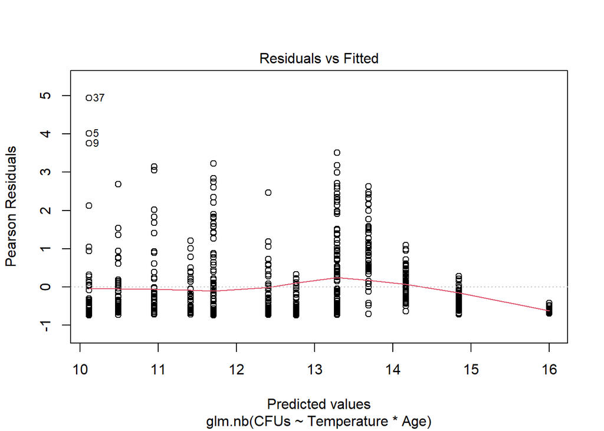

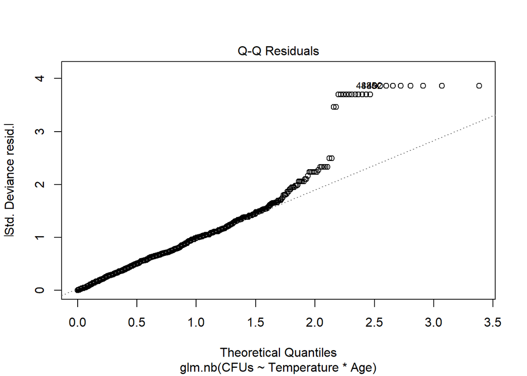

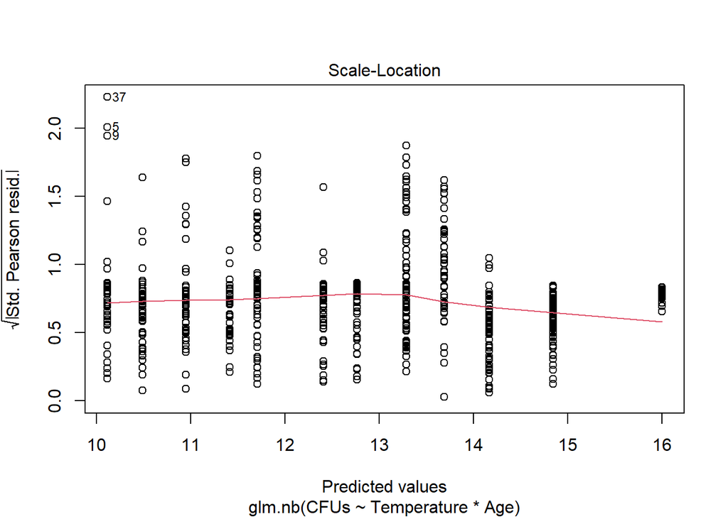

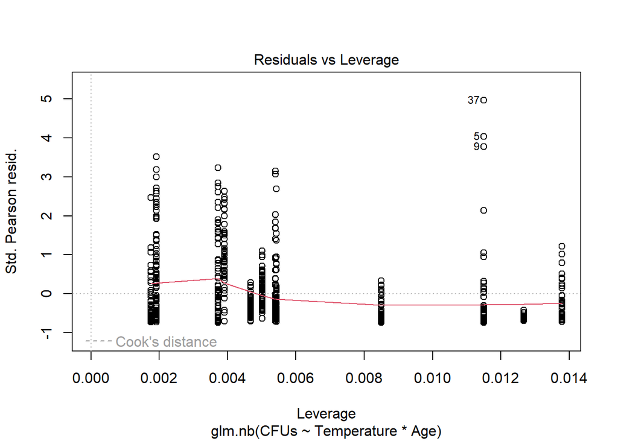

```r
plot(glmNegBinomial)
```

```r
#Residual deviance:  867.08  on 692  degrees of freedom
#AIC: 18787
# 2 x log-likelihood:  -18776.9520
#Theta:  0.5549
#Std. Err.:  0.0255


summary(glmNegBinomial_additive)
```

```
##
## Call:
## glm.nb(formula = CFUs ~ Temperature + Age, data = II_Data, link = "log",
##     init.theta = 0.5454901466)
##
## Coefficients:
##             Estimate Std. Error z value Pr(>|z|)
## (Intercept) 12.64740    0.05132  246.43   <2e-16 ***
## Temperature  0.67969    0.02652   25.63   <2e-16 ***
## Age          0.15995    0.01018   15.71   <2e-16 ***
## ---
## Signif. codes:  0 '***' 0.001 '**' 0.01 '*' 0.05 '.' 0.1 ' ' 1
##
## (Dispersion parameter for Negative Binomial(0.5455) family taken to be 1)
##
##     Null deviance: 1463.74  on 695  degrees of freedom
## Residual deviance:  868.84  on 693  degrees of freedom
## AIC: 18801
##
## Number of Fisher Scoring iterations: 1
##
##
##               Theta:  0.5455
##           Std. Err.:  0.0250
##
##  2 x log-likelihood:  -18793.1080
```

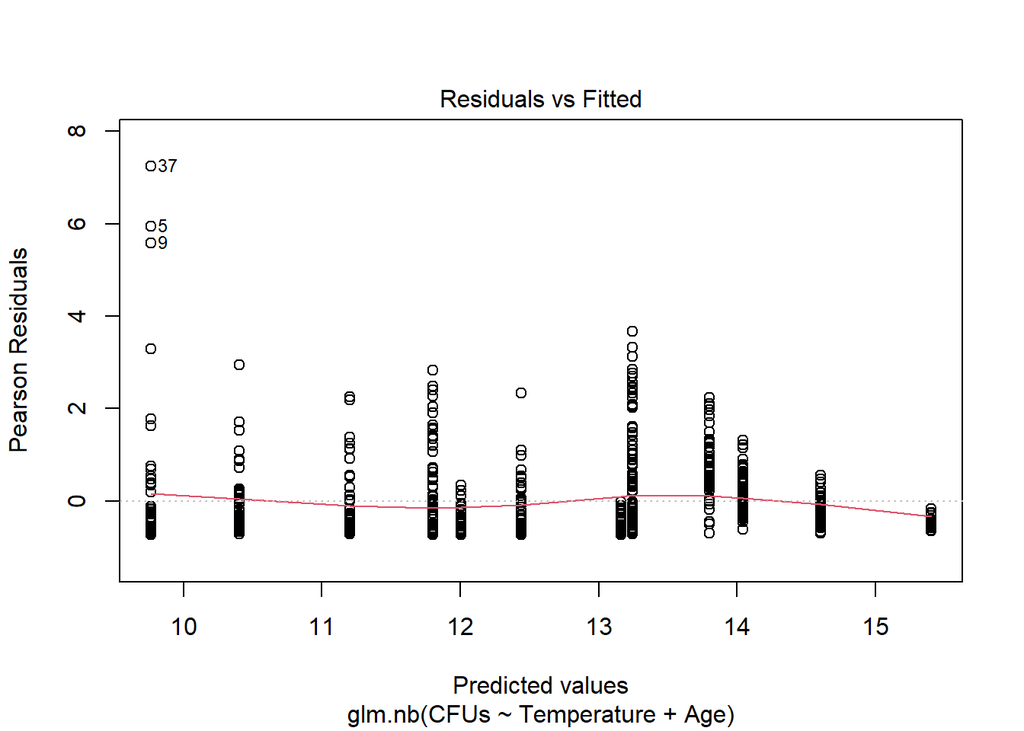

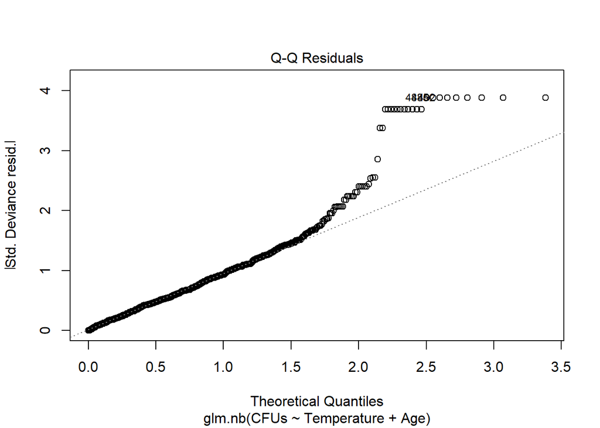

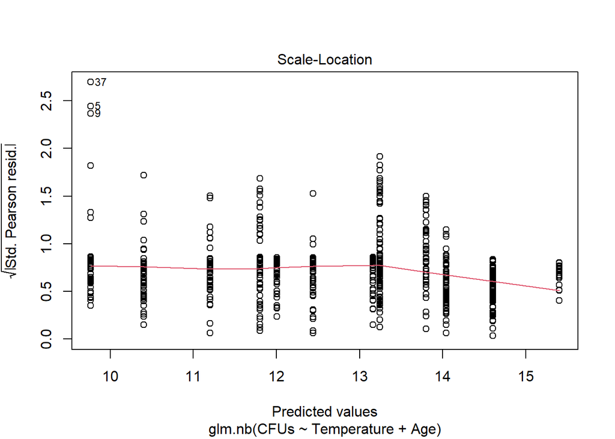

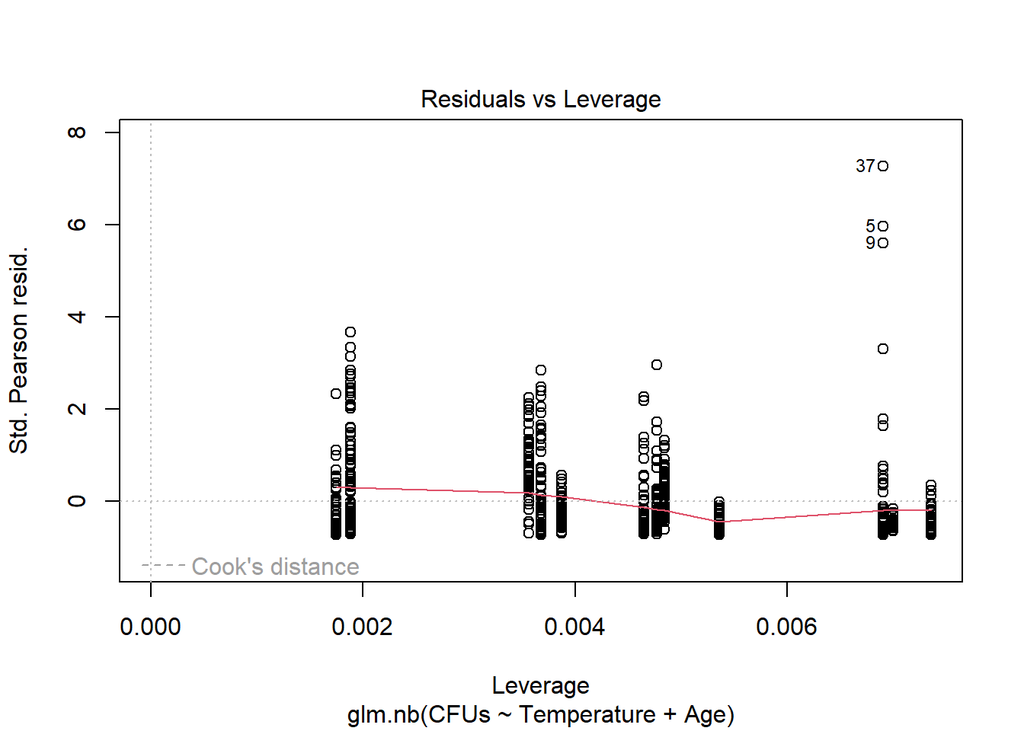

```r
plot(glmNegBinomial_additive)
```

```r
#Residual deviance:  868.84  on 693  degrees of freedom
#AIC: 18801
#Theta:  0.5455
#Std. Err.:  0.0250
# 2 x log-likelihood:  -18793.1080
```

So far, it looks like the negative binomial distribution is the better fit.

Does this match the assumption of overdispersion in the Poisson model? How does the negative binomial model compare to the poisson model?

```r
###
#checking for overdispersion in Poisson model:
E2 <- resid(glmPoisson, type = "pearson")
N  <- nrow(II_Data)
p  <- length(coef(glmPoisson))
sum(E2^2) / (N - p) # =  550206.2 #overdispersion present!
```

```
## [1] 550206.2
```

```r
#show it another way:
#how much larger/smaller is the variance relative to the mean for the poisson?
pr <- residuals(glmPoisson,"pearson")
phi <- sum(pr^2)/df.residual(glmPoisson)
round(c(phi,sqrt(phi)),4) #variance is 550206x the mean
```

```
## [1] 550206.1879    741.7588
```

```r
qchisq(0.95, df.residual(glmNegBinomial)) #this gives the threshold value
```

```
## [1] 754.3079
```

```r
#threshold value for this model is 754.3079
deviance(glmNegBinomial) #deviance = 867
```

```
## [1] 867.0777
```

```r
pr <- residuals(glmNegBinomial,"pearson")
sum(pr^2) #pearson chi square value - compare to the threshold, if greater, not signif
```

```
## [1] 527.523
```

```r
#chi square value is less than threshold at 527
#suggests model is a good fit

#for negative binomial model, need to use log likelihood to compare to poisson model
-2*(logLik(glmPoisson)-logLik(glmNegBinomial))
```

```
## 'log Lik.' 342531131 (df=4)
```

```r
#'log Lik.' 342531131 (df=4) when temp and age are continuous vars.
#'log Lik.' 193430370 (df=12) for categorical predictor vars.
lrtest(glmPoisson,glmNegBinomial)
```

```
## Likelihood ratio test
##
## Model 1: CFUs ~ Temperature * Age
## Model 2: CFUs ~ Temperature * Age
##   #Df     LogLik Df     Chisq Pr(>Chisq)
## 1   4 -171274954
## 2   5      -9388  1 342531131  < 2.2e-16 ***
## ---
## Signif. codes:  0 '***' 0.001 '**' 0.01 '*' 0.05 '.' 0.1 ' ' 1
```

```r
#chisq=342531131;  pr(>chisq) = < 2.2e-16 ***
#Neg binom is best fit compared to Poisson model

#also should compare diff neg binomial model options (should the interaction term be included in the model?)
glmNegBinomial <- glm.nb(CFUs ~ Temperature*Age, data=II_Data,link="log")
glmNegBinomial_additive <- glm.nb(CFUs ~ Temperature+Age, data=II_Data,link="log") #leaves out interaction term
anova(glmNegBinomial,glmNegBinomial_additive)
```

```
## Likelihood ratio tests of Negative Binomial Models
##
## Response: CFUs
##               Model     theta Resid. df    2 x log-lik.   Test    df LR stat.
## 1 Temperature + Age 0.5454901       693       -18793.11
## 2 Temperature * Age 0.5548731       692       -18776.95 1 vs 2     1  16.1559
##        Pr(Chi)
## 1
## 2 5.833665e-05
```

```r
#this indicates that the interaction term is a significant predictor of CFUs response
#(LR stat = 16.1559, pr(chi)=5.833665e-05)

#theta is the precision of the multiplicative random effect = 1/σ2 for the neg binom model
glmNegBinomial$theta #theta = 0.5548731
```

```
## [1] 0.5548731
```

```r
1/glmNegBinomial$theta #estimated variance = 1.802214
```

```
## [1] 1.802214
```

```r
###
# Dispersion statistic for neg binomial model:
#how much larger/smaller is the variance relative to the mean for the Neg Binomial model?
phi <- sum(pr^2)/df.residual(glmNegBinomial)
round(c(phi,sqrt(phi)),4) #variance is 0.7623 times smaller than the mean
```

```
## [1] 0.7623 0.8731
```

```r
#show another way too:
E2 <- resid(glmNegBinomial, type = "pearson")
N  <- nrow(II_Data)
p  <- length(coef(glmNegBinomial)) + 1  # '+1' is for variance in NB model
sum(E2^2) / (N - p) #= 0.763 ==== under-dispersion due to neg binomial model
```

```
## [1] 0.7634196
```

```r
#may have over-corrected for the zero inflation by using a negative binomial fit --
#check to see if other fits may be better

#################
#also check models with logCFUs to see if these may be simpler to use
#glmPoisson <- glm(logCFUs ~ Temperature*Age, data=II_Data, family = poisson(link = "log"))
#plot(glmPoisson)

#glmQuasiPoisson <- glm(logCFUs ~ Temperature*Age, data=II_Data, family = quasipoisson(link = "log"))
#summary(glmQuasiPoisson)
#plot(glmQuasiPoisson)

#glmNegBinomial <- glm.nb(logCFUs ~ Temperature*Age, data=II_Data,link="log")
#summary(glmNegBinomial)
#plot(glmNegBinomial)

#lmlogCFUs <- lm(logCFUs ~ Temperature*Age, data=II_Data)
#summary(lmlogCFUs)
#plot(lmlogCFUs)
#plot(lmlogCFUs$residuals~lmlogCFUs$fitted.values)

#pr <- residuals(lmlogCFUs,"pearson")
#phi <- sum(pr^2)/df.residual(lmlogCFUs)
#round(c(phi,sqrt(phi)),4)
#overdispersion present

#looking at plots of models - these are not very good - also not really able to transform data that's already log-transformed
```

It looks like the negative binomial model over-corrects for the overdisperison and that it does not properly account for the excess zero CFU values.

## Fitting a Zero-Inflated Negative Binomial Distribution

Helpful resources: https://www.ncbi.nlm.nih.gov/pmc/articles/PMC5628625/#:~:text=Structural%20zeros%20refer%20to%20zero,zero%20due%20to%20sampling%20variability. https://lanzaroark.org/docs/zero.pdf https://www.jstatsoft.org/article/view/v027i08 https://m-clark.github.io/models-by-example/hurdle.html https://search.r-project.org/CRAN/refmans/pscl/html/hurdle.html https://data.library.virginia.edu/getting-started-with-hurdle-models/ https://www.r-bloggers.com/2013/05/veterinary-epidemiologic-research-count-and-rate-data-zero-counts/ https://stats.oarc.ucla.edu/r/dae/negative-binomial-regression/ https://stats.oarc.ucla.edu/r/dae/zinb/

```r
library(pscl)

#try zero-inflated model instead:
#can include all covariates in each equation or make a simpler model

z1 <- zeroinfl(CFUs ~ Temperature*Age | ## Predictor for the Poisson process
                 Temperature*Age, ## Predictor for the Bernoulli process;
               dist = 'poisson',
               data = II_Data)
#z1 leads to lack of convergence

z2 <- zeroinfl(CFUs ~ Temperature*Age | ## Predictor for the Poisson process
                 1, ## Predictor for the Bernoulli process;
               dist = 'poisson',
               data = II_Data) #simple model
#z2 is the null poisson zero-inflated model
summary(z2)
```

```
##
## Call:
## zeroinfl(formula = CFUs ~ Temperature * Age | 1, data = II_Data, dist = "poisson")
##
## Pearson residuals:
##    Min     1Q Median     3Q    Max
## -5.535 -4.676 -2.360  1.589 40.440
##
## Count model coefficients (poisson with log link):
##                   Estimate Std. Error z value Pr(>|z|)
## (Intercept)      1.283e+01  8.949e-05  143330   <2e-16 ***
## Temperature      5.609e-01  4.556e-05   12310   <2e-16 ***
## Age              1.422e-01  1.485e-05    9570   <2e-16 ***
## Temperature:Age -1.862e-02  7.915e-06   -2352   <2e-16 ***
##
## Zero-inflation model coefficients (binomial with logit link):
##             Estimate Std. Error z value Pr(>|z|)
## (Intercept)  -3.4222     0.2167   -15.8   <2e-16 ***
## ---
## Signif. codes:  0 '***' 0.001 '**' 0.01 '*' 0.05 '.' 0.1 ' ' 1
##
## Number of iterations in BFGS optimization: 1
## Log-likelihood: -1.634e+08 on 5 Df
```

```r
#z3 is the null neg bin. zero-inflated model
z3 <- zeroinfl(CFUs ~ Temperature*Age | ## Predictor for the Poisson process
                 1, ## Predictor for the Bernoulli process;
               dist = 'negbin',
               data = II_Data)
summary(z3)
```

```
##
## Call:
## zeroinfl(formula = CFUs ~ Temperature * Age | 1, data = II_Data, dist = "negbin")
##
## Pearson residuals:
##     Min      1Q  Median      3Q     Max
## -0.8665 -0.6830 -0.3692  0.3006  5.8008
##
## Count model coefficients (negbin with log link):
##                  Estimate Std. Error z value Pr(>|z|)
## (Intercept)     12.673200   0.043297 292.704  < 2e-16 ***
## Temperature      0.708936   0.024319  29.152  < 2e-16 ***
## Age              0.158466   0.009528  16.632  < 2e-16 ***
## Temperature:Age  0.024016   0.005725   4.195 2.73e-05 ***
## Log(theta)      -0.229651   0.047153  -4.870 1.11e-06 ***
##
## Zero-inflation model coefficients (binomial with logit link):
##             Estimate Std. Error z value Pr(>|z|)
## (Intercept)  -3.4222     0.2169  -15.78   <2e-16 ***
## ---
## Signif. codes:  0 '***' 0.001 '**' 0.01 '*' 0.05 '.' 0.1 ' ' 1
##
## Theta = 0.7948
## Number of iterations in BFGS optimization: 1
## Log-likelihood: -9305 on 6 Df
```

```r
z4 <- zeroinfl(CFUs ~ Temperature*Age | Temperature*Age ## Predictor for the Poisson process
               , ## Predictor for the Bernoulli process;
               dist = 'negbin',
               data = II_Data)
summary(z4)
```

```
##
## Call:
## zeroinfl(formula = CFUs ~ Temperature * Age | Temperature * Age, data = II_Data,
##     dist = "negbin")
##
## Pearson residuals:
##     Min      1Q  Median      3Q     Max
## -0.8780 -0.6871 -0.3716  0.2811  5.8461
##
## Count model coefficients (negbin with log link):
##                  Estimate Std. Error z value Pr(>|z|)
## (Intercept)     12.673250   0.043283 292.797  < 2e-16 ***
## Temperature      0.708933   0.024312  29.160  < 2e-16 ***
## Age              0.158476   0.009525  16.638  < 2e-16 ***
## Temperature:Age  0.024015   0.005723   4.196 2.71e-05 ***
## Log(theta)      -0.229016   0.047031  -4.869 1.12e-06 ***
##
## Zero-inflation model coefficients (binomial with logit link):
##                   Estimate Std. Error z value Pr(>|z|)
## (Intercept)      -30.44964 2989.22641  -0.010    0.992
## Temperature       -0.12685 1465.74624   0.000    1.000
## Age               -4.48973  474.47988  -0.009    0.992
## Temperature:Age   -0.05707  232.65594   0.000    1.000
## ---
## Signif. codes:  0 '***' 0.001 '**' 0.01 '*' 0.05 '.' 0.1 ' ' 1
##
## Theta = 0.7953
## Number of iterations in BFGS optimization: 7
## Log-likelihood: -9274 on 9 Df
```

```r
#z4 leads to lack of convergence; Std errors of ZI model are too large

z5 <- zeroinfl(CFUs ~ Temperature*Age | Temperature+Age ## Predictor for the Poisson process
               , ## Predictor for the Bernoulli process;
               dist = 'negbin',
               data = II_Data)
summary(z5)
```

```
##
## Call:
## zeroinfl(formula = CFUs ~ Temperature * Age | Temperature + Age, data = II_Data,
##     dist = "negbin")
##
## Pearson residuals:
##     Min      1Q  Median      3Q     Max
## -0.8780 -0.6871 -0.3715  0.2812  5.8435
##
## Count model coefficients (negbin with log link):
##                  Estimate Std. Error z value Pr(>|z|)
## (Intercept)     12.673244   0.043285 292.785  < 2e-16 ***
## Temperature      0.708893   0.024313  29.157  < 2e-16 ***
## Age              0.158450   0.009525  16.635  < 2e-16 ***
## Temperature:Age  0.024020   0.005723   4.197 2.70e-05 ***
## Log(theta)      -0.229099   0.047033  -4.871 1.11e-06 ***
##
## Zero-inflation model coefficients (binomial with logit link):
##              Estimate Std. Error z value Pr(>|z|)
## (Intercept)  -30.5347  2953.1435  -0.010   0.9918
## Temperature    0.2322     0.1368   1.697   0.0897 .
## Age           -4.5033   468.7523  -0.010   0.9923
## ---
## Signif. codes:  0 '***' 0.001 '**' 0.01 '*' 0.05 '.' 0.1 ' ' 1
##
## Theta = 0.7952
## Number of iterations in BFGS optimization: 8
## Log-likelihood: -9274 on 8 Df
```

```r
#z5 leads to lack of convergence; Std errors of ZI model  coeff for Intercept and Age are too large

z6 <- zeroinfl(CFUs ~ Temperature*Age | Temperature ## Predictor for the Poisson process
               , ## Predictor for the Bernoulli process;
               dist = 'negbin',
               data = II_Data)
summary(z6)
```

```
##
## Call:
## zeroinfl(formula = CFUs ~ Temperature * Age | Temperature, data = II_Data,
##     dist = "negbin")
##
## Pearson residuals:
##     Min      1Q  Median      3Q     Max
## -0.8796 -0.6843 -0.3662  0.2947  5.7760
##
## Count model coefficients (negbin with log link):
##                  Estimate Std. Error z value Pr(>|z|)
## (Intercept)     12.673192   0.043299 292.694  < 2e-16 ***
## Temperature      0.708933   0.024320  29.150  < 2e-16 ***
## Age              0.158521   0.009528  16.637  < 2e-16 ***
## Temperature:Age  0.024019   0.005725   4.195 2.73e-05 ***
## Log(theta)      -0.229714   0.047191  -4.868 1.13e-06 ***
##
## Zero-inflation model coefficients (binomial with logit link):
##             Estimate Std. Error z value Pr(>|z|)
## (Intercept)  -3.5192     0.2393 -14.708   <2e-16 ***
## Temperature   0.2419     0.1291   1.874    0.061 .
## ---
## Signif. codes:  0 '***' 0.001 '**' 0.01 '*' 0.05 '.' 0.1 ' ' 1
##
## Theta = 0.7948
## Number of iterations in BFGS optimization: 2
## Log-likelihood: -9303 on 7 Df
```

```r
z7 <- zeroinfl(CFUs ~ Temperature*Age | Age ## Predictor for the Poisson process
               , ## Predictor for the Bernoulli process;
               dist = 'negbin',
               data = II_Data)
summary(z7)
```

```
##
## Call:
## zeroinfl(formula = CFUs ~ Temperature * Age | Age, data = II_Data, dist = "negbin")
##
## Pearson residuals:
##     Min      1Q  Median      3Q     Max
## -0.8781 -0.6805 -0.3677  0.2810  5.9521
##
## Count model coefficients (negbin with log link):
##                  Estimate Std. Error z value Pr(>|z|)
## (Intercept)     12.673255   0.043282 292.805  < 2e-16 ***
## Temperature      0.708885   0.024311  29.159  < 2e-16 ***
## Age              0.158457   0.009524  16.637  < 2e-16 ***
## Temperature:Age  0.024015   0.005723   4.196 2.71e-05 ***
## Log(theta)      -0.228962   0.047021  -4.869 1.12e-06 ***
##
## Zero-inflation model coefficients (binomial with logit link):
##             Estimate Std. Error z value Pr(>|z|)
## (Intercept)  -30.508   2983.715   -0.01    0.992
## Age           -4.515    473.605   -0.01    0.992
## ---
## Signif. codes:  0 '***' 0.001 '**' 0.01 '*' 0.05 '.' 0.1 ' ' 1
##
## Theta = 0.7954
## Number of iterations in BFGS optimization: 9
## Log-likelihood: -9276 on 7 Df
```

```r
#z7 leads to lack of convergence; Std errors of ZI model Int and Age are too large
```

## Model Selection

Which zero-inflated negative binomial model is better? Is the zero-inflated negative binomial model better than a regular negative binomial model?

```r
#are predictors important to the model?
lrtest(z3,z4) #yes, the complex model is better (z4)
```

```
## Likelihood ratio test
##
## Model 1: CFUs ~ Temperature * Age | 1
## Model 2: CFUs ~ Temperature * Age | Temperature * Age
##   #Df  LogLik Df  Chisq Pr(>Chisq)
## 1   6 -9305.0
## 2   9 -9274.5  3 60.989  3.614e-13 ***
## ---
## Signif. codes:  0 '***' 0.001 '**' 0.01 '*' 0.05 '.' 0.1 ' ' 1
```

```r
AIC(z3,z4) #but z3 has fewer df, relatively similar AIC
```

```
##    df      AIC
## z3  6 18621.95
## z4  9 18566.96
```

```r
#do we need to include the interaction term for the second part of the model?
lrtest(z4,z5) #NS - go with z5 - do not include interaction in 2nd half
```

```
## Likelihood ratio test
##
## Model 1: CFUs ~ Temperature * Age | Temperature * Age
## Model 2: CFUs ~ Temperature * Age | Temperature + Age
##   #Df  LogLik Df Chisq Pr(>Chisq)
## 1   9 -9274.5
## 2   8 -9274.5 -1     0      0.997
```

```r
lrtest(z5,z6) #include age in 2nd half
```

```
## Likelihood ratio test
##
## Model 1: CFUs ~ Temperature * Age | Temperature + Age
## Model 2: CFUs ~ Temperature * Age | Temperature
##   #Df  LogLik Df  Chisq Pr(>Chisq)
## 1   8 -9274.5
## 2   7 -9303.0 -1 56.987  4.388e-14 ***
## ---
## Signif. codes:  0 '***' 0.001 '**' 0.01 '*' 0.05 '.' 0.1 ' ' 1
```

```r
lrtest(z5,z7) #NS - can exclude temperature
```

```
## Likelihood ratio test
##
## Model 1: CFUs ~ Temperature * Age | Temperature + Age
## Model 2: CFUs ~ Temperature * Age | Age
##   #Df  LogLik Df  Chisq Pr(>Chisq)
## 1   8 -9274.5
## 2   7 -9276.1 -1 3.1976    0.07375 .
## ---
## Signif. codes:  0 '***' 0.001 '**' 0.01 '*' 0.05 '.' 0.1 ' ' 1
```

```r
###
#However, upon inspection:
summary(z7)
```

```
##
## Call:
## zeroinfl(formula = CFUs ~ Temperature * Age | Age, data = II_Data, dist = "negbin")
##
## Pearson residuals:
##     Min      1Q  Median      3Q     Max
## -0.8781 -0.6805 -0.3677  0.2810  5.9521
##
## Count model coefficients (negbin with log link):
##                  Estimate Std. Error z value Pr(>|z|)
## (Intercept)     12.673255   0.043282 292.805  < 2e-16 ***
## Temperature      0.708885   0.024311  29.159  < 2e-16 ***
## Age              0.158457   0.009524  16.637  < 2e-16 ***
## Temperature:Age  0.024015   0.005723   4.196 2.71e-05 ***
## Log(theta)      -0.228962   0.047021  -4.869 1.12e-06 ***
##
## Zero-inflation model coefficients (binomial with logit link):
##             Estimate Std. Error z value Pr(>|z|)
## (Intercept)  -30.508   2983.715   -0.01    0.992
## Age           -4.515    473.605   -0.01    0.992
## ---
## Signif. codes:  0 '***' 0.001 '**' 0.01 '*' 0.05 '.' 0.1 ' ' 1
##
## Theta = 0.7954
## Number of iterations in BFGS optimization: 9
## Log-likelihood: -9276 on 7 Df
```

```r
#standard errors of zero model for z7 are super large and unlikely

#null model only for both parts:
z0 <- update(z5, . ~ 1)
summary(z0)
```

```
##
## Call:
## zeroinfl(formula = CFUs ~ 1, data = II_Data, dist = "negbin")
##
## Pearson residuals:
##     Min      1Q  Median      3Q     Max
## -0.6328 -0.6106 -0.4653  0.4483  3.0641
##
## Count model coefficients (negbin with log link):
##             Estimate Std. Error z value Pr(>|z|)
## (Intercept) 13.46227    0.05958  225.97   <2e-16 ***
## Log(theta)  -0.87359    0.04676  -18.68   <2e-16 ***
##
## Zero-inflation model coefficients (binomial with logit link):
##             Estimate Std. Error z value Pr(>|z|)
## (Intercept)  -3.5052     0.2359  -14.86   <2e-16 ***
## ---
## Signif. codes:  0 '***' 0.001 '**' 0.01 '*' 0.05 '.' 0.1 ' ' 1
##
## Theta = 0.4174
## Number of iterations in BFGS optimization: 6
## Log-likelihood: -9604 on 3 Df
```

```r
lrtest(z0,z5)
```

```
## Likelihood ratio test
##
## Model 1: CFUs ~ 1
## Model 2: CFUs ~ Temperature * Age | Temperature + Age
##   #Df  LogLik Df  Chisq Pr(>Chisq)
## 1   3 -9604.5
## 2   8 -9274.5  5 659.97  < 2.2e-16 ***
## ---
## Signif. codes:  0 '***' 0.001 '**' 0.01 '*' 0.05 '.' 0.1 ' ' 1
```

```r
lrtest(z0,z7) #complex model is better than null model
```

```
## Likelihood ratio test
##
## Model 1: CFUs ~ 1
## Model 2: CFUs ~ Temperature * Age | Age
##   #Df  LogLik Df  Chisq Pr(>Chisq)
## 1   3 -9604.5
## 2   7 -9276.1  4 656.77  < 2.2e-16 ***
## ---
## Signif. codes:  0 '***' 0.001 '**' 0.01 '*' 0.05 '.' 0.1 ' ' 1
```

```r
z8 <- zeroinfl(CFUs ~ Temperature+Age | Age ## Predictor for the Poisson process
               , ## Predictor for the Bernoulli process;
               dist = 'negbin',
               data = II_Data)
summary(z8) #overfitting
```

```
##
## Call:
## zeroinfl(formula = CFUs ~ Temperature + Age | Age, data = II_Data, dist = "negbin")
##
## Pearson residuals:
##     Min      1Q  Median      3Q     Max
## -0.8702 -0.6852 -0.3719  0.2903  8.3084
##
## Count model coefficients (negbin with log link):
##              Estimate Std. Error z value Pr(>|z|)
## (Intercept) 12.680604   0.043651 290.499  < 2e-16 ***
## Temperature  0.690586   0.024617  28.053  < 2e-16 ***
## Age          0.150110   0.009353  16.050  < 2e-16 ***
## Log(theta)  -0.247966   0.046944  -5.282 1.28e-07 ***
##
## Zero-inflation model coefficients (binomial with logit link):
##             Estimate Std. Error z value Pr(>|z|)
## (Intercept)  -30.508   2983.815   -0.01    0.992
## Age           -4.515    473.621   -0.01    0.992
## ---
## Signif. codes:  0 '***' 0.001 '**' 0.01 '*' 0.05 '.' 0.1 ' ' 1
##
## Theta = 0.7804
## Number of iterations in BFGS optimization: 6
## Log-likelihood: -9285 on 6 Df
```

```r
z9 <- zeroinfl(CFUs ~ Temperature+Age | Temperature+Age ## Predictor for the Poisson process
               , ## Predictor for the Bernoulli process;
               dist = 'negbin',
               data = II_Data) #overfitting
summary(z9)
```

```
##
## Call:
## zeroinfl(formula = CFUs ~ Temperature + Age | Temperature + Age, data = II_Data,
##     dist = "negbin")
##
## Pearson residuals:
##     Min      1Q  Median      3Q     Max
## -0.8702 -0.6829 -0.3707  0.2903  8.1767
##
## Count model coefficients (negbin with log link):
##              Estimate Std. Error z value Pr(>|z|)
## (Intercept) 12.680590   0.043654 290.481  < 2e-16 ***
## Temperature  0.690637   0.024619  28.053  < 2e-16 ***
## Age          0.150114   0.009353  16.049  < 2e-16 ***
## Log(theta)  -0.248098   0.046960  -5.283 1.27e-07 ***
##
## Zero-inflation model coefficients (binomial with logit link):
##              Estimate Std. Error z value Pr(>|z|)
## (Intercept)  -30.5347  2952.9382  -0.010   0.9917
## Temperature    0.2325     0.1369   1.698   0.0895 .
## Age           -4.5032   468.7197  -0.010   0.9923
## ---
## Signif. codes:  0 '***' 0.001 '**' 0.01 '*' 0.05 '.' 0.1 ' ' 1
##
## Theta = 0.7803
## Number of iterations in BFGS optimization: 6
## Log-likelihood: -9283 on 7 Df
```

```r
lrtest(z5,z8)
```

```
## Likelihood ratio test
##
## Model 1: CFUs ~ Temperature * Age | Temperature + Age
## Model 2: CFUs ~ Temperature + Age | Age
##   #Df  LogLik Df  Chisq Pr(>Chisq)
## 1   8 -9274.5
## 2   6 -9284.7 -2 20.342  3.827e-05 ***
## ---
## Signif. codes:  0 '***' 0.001 '**' 0.01 '*' 0.05 '.' 0.1 ' ' 1
```

```r
lrtest(z7,z8)
```

```
## Likelihood ratio test
##
## Model 1: CFUs ~ Temperature * Age | Age
## Model 2: CFUs ~ Temperature + Age | Age
##   #Df  LogLik Df  Chisq Pr(>Chisq)
## 1   7 -9276.1
## 2   6 -9284.7 -1 17.144  3.465e-05 ***
## ---
## Signif. codes:  0 '***' 0.001 '**' 0.01 '*' 0.05 '.' 0.1 ' ' 1
```

```r
lrtest(z9,z5) #better to include interaction in count model
```

```
## Likelihood ratio test
##
## Model 1: CFUs ~ Temperature + Age | Temperature + Age
## Model 2: CFUs ~ Temperature * Age | Temperature + Age
##   #Df  LogLik Df Chisq Pr(>Chisq)
## 1   7 -9283.1
## 2   8 -9274.5  1 17.14  3.473e-05 ***
## ---
## Signif. codes:  0 '***' 0.001 '**' 0.01 '*' 0.05 '.' 0.1 ' ' 1
```

```r
############
#try alternate methods for model selection:
require(pscl)
require(mpath)
zfull <- zeroinfl(CFUs ~ Temperature*Age | Temperature*Age ## Predictor for the Poisson process
                  , ## Predictor for the Bernoulli process;
 dist = 'negbin', data = II_Data)
#chrome-extension://efaidnbmnnnibpcajpcglclefindmkaj/https://cran.r-project.org/web/packages/mpath/vignettes/static_german.pdf

#stepwise backward selection from full model:
#be.zeroinfl()
fitbe_z4 <- be.zeroinfl(zfull, data=II_Data, dist="negbin", alpha=0.01)
summary(fitbe_z4)
```

```
##
## Call:
## zeroinfl(formula = eval(parse(text = out)), data = data, dist = dist)
##
## Pearson residuals:
##     Min      1Q  Median      3Q     Max
## -0.8665 -0.6830 -0.3692  0.3006  5.8008
##
## Count model coefficients (negbin with log link):
##                  Estimate Std. Error z value Pr(>|z|)
## (Intercept)     12.673200   0.043297 292.704  < 2e-16 ***
## Temperature      0.708936   0.024319  29.152  < 2e-16 ***
## Age              0.158466   0.009528  16.632  < 2e-16 ***
## Temperature:Age  0.024016   0.005725   4.195 2.73e-05 ***
## Log(theta)      -0.229651   0.047153  -4.870 1.11e-06 ***
##
## Zero-inflation model coefficients (binomial with logit link):
##             Estimate Std. Error z value Pr(>|z|)
## (Intercept)  -3.4222     0.2169  -15.78   <2e-16 ***
## ---
## Signif. codes:  0 '***' 0.001 '**' 0.01 '*' 0.05 '.' 0.1 ' ' 1
##
## Theta = 0.7948
## Number of iterations in BFGS optimization: 1
## Log-likelihood: -9305 on 6 Df
```

```r
#summarystepwise <-  #read.table('stepwiseselectionmodel.txt',sep='\t')

#this is model z3
cat("log-liklihood of zero-inflated model with backward selection",logLik(fitbe_z4))
```

```
## log-liklihood of zero-inflated model with backward selection -9304.976
```

```r
cat("BIC of zero-inflated model with backward selection",AIC(fitbe_z4,k=log(dim(II_Data)[1])))
```

```
## BIC of zero-inflated model with backward selection 18649.22
```

```r
fitbe_z4$formula
```

```
## CFUs ~ Temperature + Age + Temperature:Age | 1
## <environment: 0x0000020213012140>
```

```r
#this is model z3 - avoids overfitting of z7 and has relatively low AIC - best choice
```

The stepwise backward selection suggests the null zero-inflation component is the simplest, best fit model - this avoids lack of convergence.

Compare the models:

```r
#https://www.jstatsoft.org/article/view/v027i08 source for model estimations
#compare Max-liklihood estimators for different models:
model_list <- list("ML-Pois" = glmPoisson, "Quasi-Pois" = glmQuasiPoisson, "NB" = glmNegBinomial,"ZINB" = z3)

#inspect estimated regression coefficients for each model:
sapply(model_list, function(x) coef(x)[1:5])
```

```
##                     ML-Pois  Quasi-Pois          NB        ZINB
## (Intercept)     12.79583989 12.79583989 12.64179020 12.67319953
## Temperature      0.55808012  0.55808012  0.70457225  0.70893566
## Age              0.14775368  0.14775368  0.16914506  0.15846628
## Temperature:Age -0.01739077 -0.01739077  0.02762604  0.02401647
## <NA>                     NA          NA          NA -3.42219070
```

```r
rbind(logLik = sapply(model_list, function(x) round(logLik(x), digits = 0)),
      Df = sapply(model_list, function(x) attr(logLik(x), "df")))
```

```
##           ML-Pois Quasi-Pois    NB  ZINB
## logLik -171274954         NA -9388 -9305
## Df              4          5     5     6
```

```r
#compare AIC values now:
Model_AICs <- c(PoisAIC = AIC(glmPoisson),NegBinAIC=AIC(glmNegBinomial),ZeroInfl_AIC = AIC(z3))
Model_AICs
```

```
##      PoisAIC    NegBinAIC ZeroInfl_AIC
## 342549916.11     18786.95     18621.95
```

```r
#ML-Pois and Quasi-Pois can be eliminated
#better models are NB and ZINB
#NB is improved by addition of zinb
```

### The negative binomial model is improved by the addition of the zero-inflation component.

The ZINB model has a larger log-likelihood (less negative value) and smaller AIC value.

```r
######
#how are the zeros captured by the models?
gc() #clear memory to make space for computation
```

```
##           used  (Mb) gc trigger  (Mb)  max used  (Mb)
## Ncells 3176464 169.7    6239492 333.3   6239492 333.3
## Vcells 5771421  44.1  106202438 810.3 129564785 988.6
```

```r
#can run this to get the value of 22 below (takes awhile)
zinb_predictions <- predict(z3, type = "prob") #even more computationally intensive - too large to process in R alone
str(zinb_predictions)
```

```
##  num [1:696, 1:3984001] 0.0319 0.0319 0.0319 0.0319 0.0319 ...
##  - attr(*, "dimnames")=List of 2
##   ..$ : chr [1:696] "1" "2" "3" "4" ...
##   ..$ : chr [1:3984001] "0" "1" "2" "3" ...
```

```r
#type=prob gives probabilities of counts
#22/696 = 0.03

observed_zeros <- round(sum(II_Data$CFUs < 1))
Pois_zeros <- round(sum(dpois(0, fitted(glmPoisson))))
NegBin_zeros <- round(sum(dnbinom(0, mu = fitted(glmNegBinomial), size = glmNegBinomial$theta)))
#zinb_zeros <- round(sum(zinb_predictions[,1])) #=22
zinb_zeros <- 22 #get value of 22 in line above

comparing_zeros <- c("Obs"=observed_zeros,"ML-Pois"=Pois_zeros,"NB"=NegBin_zeros,"ZINB"=zinb_zeros)
comparing_zeros
```

```
##     Obs ML-Pois      NB    ZINB
##      22       0       1      22
```

```r
#zero-inflated negative binomial model seems to be the best fit

#check the dispersion statistic:
E2 <- resid(z3, type = "pearson")
N  <- nrow(II_Data)
p  <- length(coef(z3)) + 1  # '+1' is for variance in NB model
sum(E2^2) / (N - p)
```

```
## [1] 1.015058
```

```r
# = 1.015009, close to 1 = good
#closer to 1 than the negative binomial model



#are the z3 model parameters important? yes.
library(car)
Anova(z3,
      type="II",
      test="Chisq")
```

```
## Analysis of Deviance Table (Type II tests)
##
## Response: CFUs
##                 Df   Chisq Pr(>Chisq)
## Temperature      1 832.410  < 2.2e-16 ***
## Age              1 259.224  < 2.2e-16 ***
## Temperature:Age  1  17.599  2.727e-05 ***
## ---
## Signif. codes:  0 '***' 0.001 '**' 0.01 '*' 0.05 '.' 0.1 ' ' 1
```

```r
#is z3 model better than the null zi model?
library(rcompanion)
nagelkerke(z3) #yes
```

```
## $Models
##
## Model: "zeroinfl, CFUs ~ Temperature * Age | 1, II_Data, negbin"
## Null:  "zeroinfl, CFUs ~ 1, II_Data, negbin"
##
## $Pseudo.R.squared.for.model.vs.null
##                              Pseudo.R.squared
## McFadden                            0.0311824
## Cox and Snell (ML)                  0.5770930
## Nagelkerke (Cragg and Uhler)        0.5770930
##
## $Likelihood.ratio.test
##  Df.diff LogLik.diff  Chisq     p.value
##       -3     -299.49 598.98 1.6767e-129
##
## $Number.of.observations
##
## Model: 696
## Null:  696
##
## $Messages
## [1] "Note: For models fit with REML, these statistics are based on refitting with ML"
##
## $Warnings
## [1] "None"
```

Using the zero-inflated negative binomial model, we can predict what the expected CFU counts would be for each temperature-age combination, and we can compare these values to the observed values. We can also identify how the zero-inflation component affects the expected CFU count.

```r
#create data frame for predictions:
newdata1 <- expand.grid(c(-2.76,0.24,2.24),rep(c(-6.3,-2.3,2.7,7.7)))
#newdata1 <- expand.grid(c(27,30,32), rep(c(1,5,10,15)))
colnames(newdata1) <- c("Temperature", "Age")

#what can we predict with the model?

#we can predict the response with and without a zero-inflation component, the probability of the CFU observation, probability of an excess zero

newdata1$count <- predict(z3, newdata1, type="count") #predicted response w/o zero inflation
newdata1$response <- predict(z3, newdata1, type="response") #predicted response (numerical) w/ zero inflation
newdata1$excesszeroprob <- predict(z3,newdata1,type="zero") #predicted predicted probabilities of zero component
newdata1$diffwzi <- (newdata1$count - newdata1$response) #this is the difference between the outcome with and without accounting for zero-inflation
```

```r
###
#https://stackoverflow.com/questions/22314921/no-zeros-predicted-from-zeroinfl-object-in-r
#https://search.r-project.org/CRAN/refmans/pscl/html/predict.zeroinfl.html

#identify which samples had zero CFU counts in the original dataset:
zerosindata <- II_Data$CFUs==0
summary(zerosindata)
```

```
##    Mode   FALSE    TRUE
## logical     674      22
```

```r
zerodata <- II_Data[which(zerosindata),]
zerodata
```

```
## # A tibble: 22 × 10
##    Trial    ID Temperature   Age  CFUs Block Infectious_Dose
##    <dbl> <dbl>       <dbl> <dbl> <dbl> <fct>           <dbl>
##  1     5     7       -2.76  -6.3     0 16             16836
##  2     5     8       -2.76  -6.3     0 16             16836
##  3     1     3        0.24  -6.3     0 4              33120
##  4     1     9        0.24  -6.3     0 4              33120
##  5     2     1        0.24  -6.3     0 5              24806.
##  6     2     2        0.24  -6.3     0 5              24806.
##  7     3     4        0.24  -6.3     0 6              12213
##  8     3    10        0.24  -6.3     0 6              12213
##  9     5     3        0.24  -6.3     0 9               7935
## 10     5     4        0.24  -6.3     0 9               7935
## # ℹ 12 more rows
## # ℹ 3 more variables: Temperature_uncentered <dbl>, Age_uncentered <dbl>,
## #   logCFUs <dbl>
```

```r
row.names(zerodata) #extract these row names (sample ID)
```

```
##  [1] "1"  "2"  "3"  "4"  "5"  "6"  "7"  "8"  "9"  "10" "11" "12" "13" "14" "15"
## [16] "16" "17" "18" "19" "20" "21" "22"
```

```r
#now, we can predict the probability of an excess zero vs. a zero predicted by the neg bin regression model
#and we can filter out these probabilities for the data that had real zero observations (above)

pzero <- predict(z3,type="zero") #prob excess zeros

proportion_prob_excess_vs_structural <- pzero / zinb_predictions[,1] #this is the proportion of predicted probability of a zero that is excess versus structural (regression)

probzerobyregression <- zinb_predictions[,1]-pzero #this gives the prob of a zero beyond the probability of an excess zero
as.data.frame(probzerobyregression)
```

```
##     probzerobyregression
## 1           2.559019e-04
## 2           2.559019e-04
## 3           2.559019e-04
## 4           2.559019e-04
## 5           2.559019e-04
## 6           2.559019e-04
## 7           2.559019e-04
## 8           2.559019e-04
## 9           2.559019e-04
## 10          2.559019e-04
## 11          2.559019e-04
## 12          2.559019e-04
## 13          2.559019e-04
## 14          2.559019e-04
```

[output cut: 682 more lines]

```r
zeroprobchart <- probzerobyregression[(row.names(zerodata))] #extract the rows that are samples with real zeros (see above)
table_prob_zeronotexcess_forgivenzeros <- cbind(zerodata,zeroprobchart) #add sample info

II_Data_wprobstructuralzero <- cbind(II_Data,probzerobyregression)

II_Data_wprobstructuralzero$excessprob <- 1 - II_Data_wprobstructuralzero$probzerobyregression
```

We can then graph these comparisons for a visual representation:

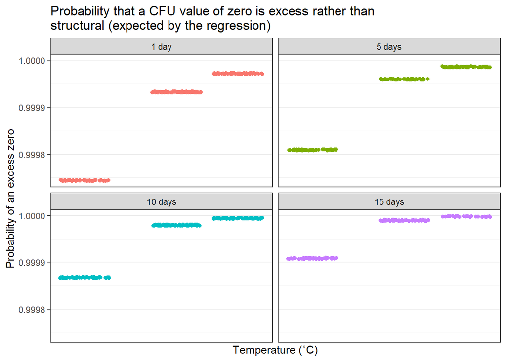

```r
#plot these comparisons:

#plot probability that the zero is structural (predicted by the regression)
#ggplot(table_prob_zeronotexcess_forgivenzeros, aes(x = Temperature, y = zeroprobchart, colour = factor(Age))) +
#  geom_point() +
#  facet_grid(~Age,labeller = labeller(Age=agelabs, Temperature=templabs)) +
#  labs(x = "Temperature", y = "Prob zero is structural")+
#  theme_bw()

#plot the probability of a zero being an excess zero for each temp/age combo:
ggplot(II_Data_wprobstructuralzero, aes(x = Temperature, y = excessprob, colour = factor(Age))) +
  geom_point() + geom_jitter()+
  geom_point(aes(x=Temperature,y=excessprob,colour=factor(Age),group=Temperature))+
  facet_wrap(~Age,labeller = labeller(Age=agelabs, Temperature=templabs)) +
  labs(x = "Temperature (˚C)", y = "Probability of an excess zero")+
  theme_bw()+
  labs(title="Probability that a CFU value of zero is excess rather than \nstructural (expected by the regression)")+
  scale_x_continuous(breaks = c(27,30,32))+
  theme(legend.position = "none")
```

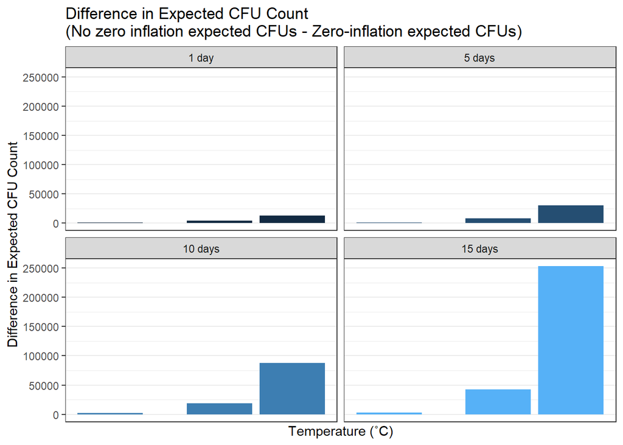

```r
#newdata1$diffwzi
ggplot(newdata1, aes(x=Temperature,y=diffwzi))+
  geom_bar(aes(fill=Age),
         stat="identity",show.legend = FALSE)+
  scale_x_continuous(breaks = c(27,30,32))+
  facet_wrap(~Age,labeller = labeller(Age=agelabs, Temperature=templabs)) +
  theme(legend.position = "none")+
  labs(x = "Temperature (˚C)", y = "Difference in Expected CFU Count")+
  theme_bw()+
  labs(title="Difference in Expected CFU Count \n(No zero inflation expected CFUs - Zero-inflation expected CFUs)")
```

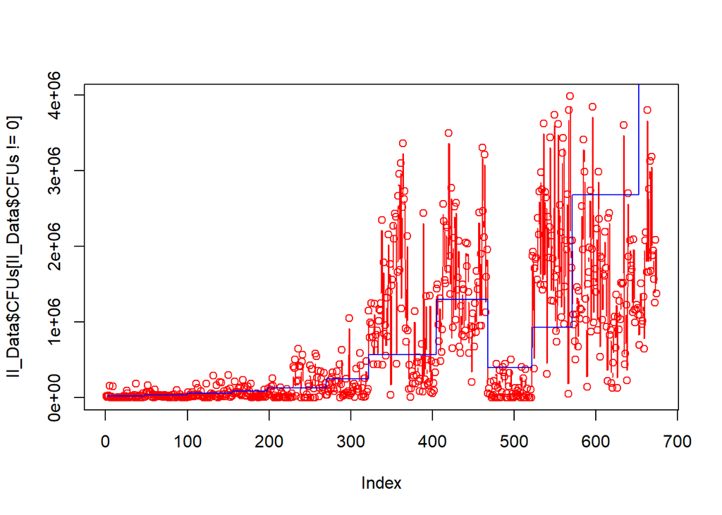

```r
predzinb <-predict(z3,newdata=II_Data[II_Data$CFUs!=0,],type="response")
plot(II_Data$CFUs[II_Data$CFUs!=0],type="b",col="red") #actual
lines(round(predzinb),col="blue") #predicted values
```

## Model Interpretation and Visualization

What is the model output and what does this mean?

```r
summary(z3)
```

```
##
## Call:
## zeroinfl(formula = CFUs ~ Temperature * Age | 1, data = II_Data, dist = "negbin")
##
## Pearson residuals:
##     Min      1Q  Median      3Q     Max
## -0.8665 -0.6830 -0.3692  0.3006  5.8008
##
## Count model coefficients (negbin with log link):
##                  Estimate Std. Error z value Pr(>|z|)
## (Intercept)     12.673200   0.043297 292.704  < 2e-16 ***
## Temperature      0.708936   0.024319  29.152  < 2e-16 ***
## Age              0.158466   0.009528  16.632  < 2e-16 ***
## Temperature:Age  0.024016   0.005725   4.195 2.73e-05 ***
## Log(theta)      -0.229651   0.047153  -4.870 1.11e-06 ***
##
## Zero-inflation model coefficients (binomial with logit link):
##             Estimate Std. Error z value Pr(>|z|)
## (Intercept)  -3.4222     0.2169  -15.78   <2e-16 ***
## ---
## Signif. codes:  0 '***' 0.001 '**' 0.01 '*' 0.05 '.' 0.1 ' ' 1
##
## Theta = 0.7948
## Number of iterations in BFGS optimization: 1
## Log-likelihood: -9305 on 6 Df
```

### Model Interpretation:

For the count model (non-zero), Temperature, Age, and the Temperature*Age Interaction are all significant predictors of the log(CFUs).

The interaction term is significant - this means that the individual coefficients for the main effects of temperature and age cannot be interpreted in the same way as they would be if no interaction were included in the model.

The estimates from the model, without transformation, are on the natural log scale and are additive (because it is a negative binomial model with a log link).

The coefficient for a one unit change in temperature only indicates an increase in log(CFUs) of 0.708936 when the value of age is at its average (due to centering) not when all variables are held constant - this is because you cannot hold both the value of main effects and the interaction term constant without changing one or the other (the interaction includes the main effect).

Temperature and age interact to increase the infection intensity (positive estimate of 0.024016).

Because the interaction term is significant, it is much more meaningful to interpret the interaction and the effects of temperature and age by looking at the marginal effects (see figures and calculations further below).

The coefficient for the interaction term indicates the additional change in the effect or slope of Temp for every unit change in Age (and vice versa).

The intercept of the count model indicates that the expected number of log(CFUs) is 12.6732, when temperature and age are held constant at their averages. Thus, when the temperature is 29.7C and the mosquito is 7 days old, the estimated number of CFUs is 319,079.

Theta equals the inverse of the dispersion parameter.

The significant p-value for the intercept for the zero-inflation model indicates that the intercept is non-zero. Therefore, the baseline odds of an excessive zero (zero inflation model) is exp(-3.4222)= 0.0326. This is an odds ratio because it is a binomial model with logit link.

We can take the estimates and back-transform them to identify how changes in temperature and age are expected to alter the CFUs (below).

#### References to review for notes, explanations, and examples:

https://stats.oarc.ucla.edu/r/seminars/interactions-r/#s3

Brambor, T., Clark, W. R., & Golder, M. (2006). Understanding Interaction Models: Improving Empirical Analyses. Political Analysis, 14(1), 63–82. http://www.jstor.org/stable/25791835

AND: https://stats.stackexchange.com/questions/31027/how-to-interpret-main-effects-when-the-interaction-effect-is-not-significant https://stats.stackexchange.com/questions/572196/how-to-interpret-an-interaction-in-a-negative-binomial https://stats.stackexchange.com/questions/180155/what-does-it-mean-intuitively-to-hold-other-variables-constant-in-regression https://stats.stackexchange.com/questions/84314/what-does-all-else-equal-mean-in-multiple-regression https://www.stata-journal.com/article.html?article=st0194

## Model Predictions: Confidence Intervals and Risk/Odds Ratios

```r
#now, use bootstrapping to find confidence intervals and
#also to determine risk/odd ratios for the parameter estimates

library(boot)

#get start values for each part of the model:
dput(round(coef(z3, "count"), 4))
```

```
## c(`(Intercept)` = 12.6732, Temperature = 0.7089, Age = 0.1585,
## `Temperature:Age` = 0.024)
```

```r
dput(round(coef(z3, "zero"), 4))
```

```
## c(`(Intercept)` = -3.4222)
```

```r
#put these values into the following equation in the function f:
f <- function(data, i) {
  require(pscl)
  z3 <- zeroinfl(CFUs ~ Temperature*Age | 1,
                 dist = 'negbin',
                 data = data[i,],
                 start = list(count = c(12.6732, 0.7089, 0.1585,0.024), zero = c(-3.4222)))
  as.vector(t(do.call(rbind, coef(summary(z3)))[, 1:2]))
}

#bootstrap:
set.seed(10)
(res <- boot(II_Data, f, R = 1200, parallel = "snow", ncpus = 4))
```

```
##
## ORDINARY NONPARAMETRIC BOOTSTRAP
##
##
## Call:
## boot(data = II_Data, statistic = f, R = 1200, parallel = "snow",
##     ncpus = 4)
##
##
## Bootstrap Statistics :
##          original        bias     std. error
## t1*  12.673194937 -4.898020e-03 0.0438823288
## t2*   0.043297691 -5.468469e-06 0.0010398671
## t3*   0.708911079  2.127967e-03 0.0244199244
## t4*   0.024319439  1.842112e-05 0.0009133508
## t5*   0.158469759  7.400656e-04 0.0094825622
## t6*   0.009527928 -1.335675e-06 0.0003657822
## t7*   0.024018138 -6.422908e-04 0.0066417829
## t8*   0.005724977  1.267517e-05 0.0002728068
## t9*  -0.229688970  6.967698e-03 0.0475506421
## t10*  0.047154132  3.113155e-05 0.0002322092
## t11* -3.424423633 -2.627904e-02 0.2304935787
## t12*  0.217123625  4.209137e-03 0.0247754290
```

```r
#the results alternate the coefficient estimates and their standard errors
#e.g. t1 is the estimate for the intercept in the conditional model, and t2 is the estimate for its standard error
```

```r
## basic parameter estimates with percentile and bias adjusted CIs
#use sapply to extract the parameter estimates and apply function:
parms <- t(sapply(c(1, 3, 5, 7, 11), function(i) {
  out <- boot.ci(res, index = c(i, i + 1), type = c("perc", "bca"))
  with(out, c(Est = t0, pLL = percent[4], pUL = percent[5],
              bcaLL = bca[4], bcaUL = bca[5]))
}))

## add row names
as.data.frame(parms)
```

```
##           Est         pLL        pUL       bcaLL       bcaUL
## 1 12.67319494 12.57794642 12.7536230 12.59284396 12.76195241
## 2  0.70891108  0.66191258  0.7587309  0.65735174  0.75214864
## 3  0.15846976  0.14139871  0.1788504  0.14042360  0.17730978
## 4  0.02401814  0.01009137  0.0362526  0.01151329  0.03804646
## 5 -3.42442363 -3.96530942 -3.0331680 -3.88967958 -2.97117852
```

```r
row.names(parms) <- names(coef(z3))

## print results for confidence intervals:
parms
```

```
##                               Est         pLL        pUL       bcaLL
## count_(Intercept)     12.67319494 12.57794642 12.7536230 12.59284396
## count_Temperature      0.70891108  0.66191258  0.7587309  0.65735174
## count_Age              0.15846976  0.14139871  0.1788504  0.14042360
## count_Temperature:Age  0.02401814  0.01009137  0.0362526  0.01151329
## zero_(Intercept)      -3.42442363 -3.96530942 -3.0331680 -3.88967958
##                             bcaUL
## count_(Intercept)     12.76195241
## count_Temperature      0.75214864
## count_Age              0.17730978
## count_Temperature:Age  0.03804646
## zero_(Intercept)      -2.97117852
```

```r
## compare with normal based approximation
confint(z3) # bootstrapped errors should be larger
```

```
##                             2.5 %      97.5 %
## count_(Intercept)     12.58833902 12.75806004
## count_Temperature      0.66127169  0.75659963
## count_Age              0.13979216  0.17714040
## count_Temperature:Age  0.01279605  0.03523688
## zero_(Intercept)      -3.84729808 -2.99708332
```

```r
#now, follow similar procedure - exponentiate estimates (using log)
#this gives us the response scale in terms of CFUs
#get incidence risk ratio (IRR) for negative binomial model (non-zeros)
#get odds ratio (OR) for logit model (zero component) (zero inflation model)

## exponentiated parameter estimates with percentile and bias adjusted CIs
expparms <- t(sapply(c(1, 3, 5, 7, 11), function(i) {
  out <- boot.ci(res, index = c(i, i + 1), type = c("perc", "bca"), h = exp)
  with(out, c(Est = t0, pLL = percent[4], pUL = percent[5],
              bcaLL = bca[4], bcaUL = bca[5]))
}))


## add row names
as.data.frame(expparms)
```

```
##            Est          pLL          pUL        bcaLL        bcaUL
## 1 3.190793e+05 2.900900e+05 3.458025e+05 2.944440e+05 3.486948e+05
## 2 2.031778e+00 1.938496e+00 2.135564e+00 1.929675e+00 2.121554e+00
## 3 1.171716e+00 1.151884e+00 1.195842e+00 1.150761e+00 1.194001e+00
## 4 1.024309e+00 1.010142e+00 1.036918e+00 1.011580e+00 1.038779e+00
## 5 3.256805e-02 1.896217e-02 4.816282e-02 2.045190e-02 5.124288e-02
```

```r
row.names(expparms) <- names(coef(z3))
## print results
expparms
```

```
##                                Est          pLL          pUL        bcaLL
## count_(Intercept)     3.190793e+05 2.900900e+05 3.458025e+05 2.944440e+05
## count_Temperature     2.031778e+00 1.938496e+00 2.135564e+00 1.929675e+00
## count_Age             1.171716e+00 1.151884e+00 1.195842e+00 1.150761e+00
## count_Temperature:Age 1.024309e+00 1.010142e+00 1.036918e+00 1.011580e+00
## zero_(Intercept)      3.256805e-02 1.896217e-02 4.816282e-02 2.045190e-02
##                              bcaUL
## count_(Intercept)     3.486948e+05
## count_Temperature     2.121554e+00
## count_Age             1.194001e+00
## count_Temperature:Age 1.038779e+00
## zero_(Intercept)      5.124288e-02
```

We can create risk and odds ratios because the parameter is the log of the ratio of expected counts (due to the distribution) (see https://stats.oarc.ucla.edu/r/dae/negative-binomial-regression/).

The exp(estimate) scale is multiplicative, but the estimate scale is additive because it is a negative binomial model.

The exponentiated estimate for the intercept tells us that when temp and age are at their average (~29.7C and 7 days old), the estimated number of CFUs per mosquito is 319,079.

With every increase in temperature (degree C), the number of CFUs is 2.03 times greater (more than doubles), given that age is held constant at the average (7 days). With every increase in age, the number of CFUs is 1.17 times greater (increases by almost 20%), given that temp is held constant at the average (29.7C). Temp and age interact significantly to increase infection intensity.

The baseline odds ratio for an excessive zero (cleared infection) is 0.03 (3%) when at 29.7C and 7 days old.

### We can visualize the predicted outcomes compared to the actual data:

```r
II_Summary
```

```
## # A tibble: 12 × 7
## # Groups:   Temperature [3]
##    Temperature   Age mean_CFUs median_CFUs sd_CFUs n_CFUs SE_CFUs
##          <dbl> <dbl>     <dbl>       <dbl>   <dbl>  <int>   <dbl>
##  1       -2.76  -6.3    24184.        9000  40608.     49   5801.
##  2       -2.76  -2.3    28317.       17250  31429.     52   4358.
##  3       -2.76   2.7    58540.       32000  70364.     55   9488.
##  4       -2.76   7.7    60395.       43000  57644.     43   8791.
##  5        0.24  -6.3   132343.       42000 174500.     83  19154.
##  6        0.24  -2.3   177981.      112500 194841.     52  27020.
##  7        0.24   2.7  1032000       832000 863025.     83  94729.
##  8        0.24   7.7  1521143.     1432000 741178.     63  93380.
##  9        2.24  -6.3   101000        28500 141758.     63  17860.
## 10        2.24  -2.3  2066082.     1932000 940495.     49 134356.
## 11        2.24   2.7  1430341.     1254000 792195.     82  87483.
## 12        2.24   7.7  1796727.     1664000 820936.     22 175024.
```

```r
newdata1
```

```
##    Temperature  Age      count   response excesszeroprob     diffwzi
## 1        -2.76 -6.3   25230.22   24432.72      0.0316091    797.5047
## 2         0.24 -6.3  134415.85  130167.08      0.0316091   4248.7642
## 3         2.24 -6.3  410018.45  397058.14      0.0316091  12960.3152
## 4        -2.76 -2.3   36480.06   35326.96      0.0316091   1153.1021
## 5         0.24 -2.3  259267.22  251072.02      0.0316091   8195.2041
## 6         2.24 -2.3  958390.04  928096.19      0.0316091  30293.8489
## 7        -2.76  2.7   57839.39   56011.14      0.0316091   1828.2513
## 8         0.24  2.7  589344.23  570715.59      0.0316091  18628.6421
## 9         2.24  2.7 2769911.60 2682357.18      0.0316091  87554.4193
## 10       -2.76  7.7   91704.76   88806.05      0.0316091   2898.7051
## 11        0.24  7.7 1339647.26 1297302.22      0.0316091  42345.0475
## 12        2.24  7.7 8005519.61 7752472.32      0.0316091 253047.2886
```

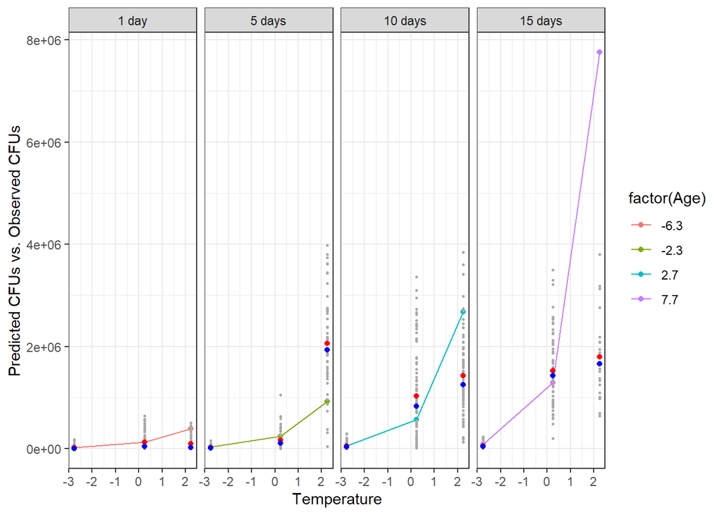

```r
ggplot(newdata1, aes(x = Temperature, y = response, colour = factor(Age))) +
  geom_point() +
  geom_line() +
  facet_grid(~Age,labeller = labeller(Age=agelabs, Temperature=templabs)) +
  labs(x = "Temperature", y = "Predicted CFUs vs. Observed CFUs")+
  geom_point(aes(x=Temperature,y=CFUs),size=(0.5),color="dark gray",data=II_Data)+
  geom_point(aes(x=Temperature,y=mean_CFUs),color="red",data=II_Summary)+
  geom_point(aes(x=Temperature,y=median_CFUs),color="blue",data=II_Summary)+
  theme_bw()
```

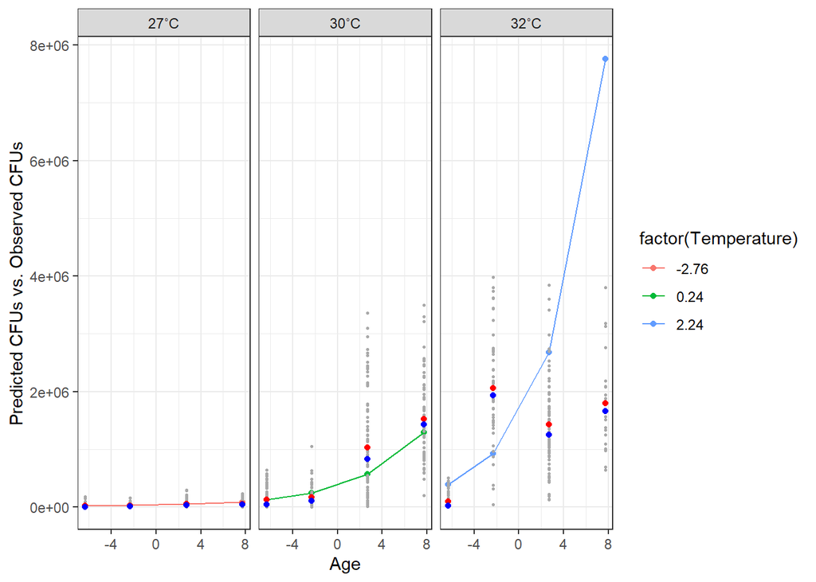

```r
ggplot(newdata1, aes(x = Age, y = response, colour=factor(Temperature))) +
  geom_point() +
  geom_line() +
  facet_grid(~Temperature,labeller = labeller(Age=agelabs, Temperature=templabs)) +
  labs(x = "Age", y = "Predicted CFUs vs. Observed CFUs")+
  geom_point(aes(x=Age,y=CFUs),size=(0.5),color="dark gray",data=II_Data)+
  geom_point(aes(x=Age,y=mean_CFUs),color="red",data=II_Summary)+
  geom_point(aes(x=Age,y=median_CFUs),color="blue",data=II_Summary)+
  theme(legend.position = "none")+
  theme_bw()
```

We can also better understand the interaction of temperature and age using interaction plots and estimated marginal means. The marginal means and effects can be reported (see tables for marginal means by temp and by age), and the visual graphs are a great representation of how temperature and age interact to change the CFU outcome. Looking at marginal means for interpreting the effects of temperature, age, and their interaction is more informative given the significant interaction of temperature and age on the expected count of CFUs.

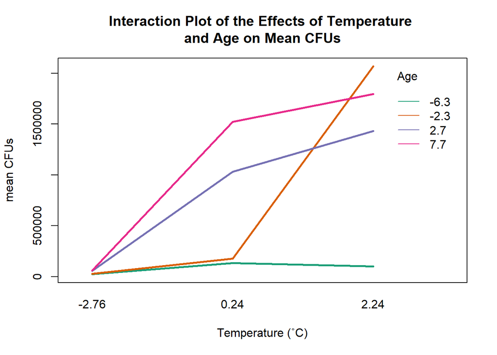

```r
#Interaction Plots and Marginal Means
#?interaction.plot()

interaction.plot(
  x.factor = II_Data$Temperature,
  trace.factor = II_Data$Age,
  response = II_Data$CFUs,
  trace.label = "Age",fixed=TRUE,
  xlab = "Temperature (˚C)", ylab = "mean CFUs",
  main = "Interaction Plot of the Effects of Temperature \nand Age on Mean CFUs",
  col = brewer.pal(n=4,name="Dark2"),
  lwd = 2.5,
  lty = 1
)
```

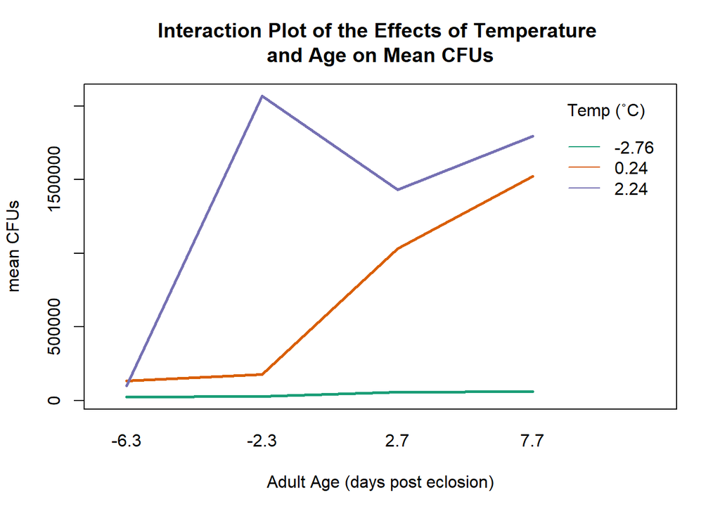

```r
interaction.plot(
  x.factor = II_Data$Age,
  trace.factor = II_Data$Temperature,
  response = II_Data$CFUs,
  trace.label = "Temp (˚C)",fixed=TRUE,
  xlab = "Adult Age (days post eclosion)", ylab = "mean CFUs",
  main = "Interaction Plot of the Effects of Temperature \nand Age on Mean CFUs",
  col = brewer.pal(n=4,name="Dark2"),
  lwd = 2.5,
  lty = 1
)
```

```r
#https://strengejacke.github.io/ggeffects/
#https://cran.r-project.org/web/packages/sjPlot/vignettes/plot_marginal_effects.html
library(ggeffects)
library(ggplot2)
library(splines)

ggpredict(z3, terms = "Temperature")
```

```
## # Predicted counts of CFUs
##
## Temperature | Predicted |               95% CI
## ----------------------------------------------
##       -2.76 |  45090.69 | [38602.06, 52670.00]
##        0.24 |  3.78e+05 | [3.47e+05, 4.12e+05]
##        2.24 |  1.56e+06 | [1.36e+06, 1.79e+06]
##
## Adjusted for:
## * Age = -0.00
```

```r
ggpredict(z3, terms = "Age")
```

```
## # Predicted counts of CFUs
##
##   Age | Predicted |               95% CI
## ----------------------------------------
## -6.30 |  1.18e+05 | [1.02e+05, 1.36e+05]
## -2.30 |  2.22e+05 | [2.02e+05, 2.44e+05]
##  2.70 |  4.91e+05 | [4.45e+05, 5.41e+05]
##  7.70 |  1.08e+06 | [9.19e+05, 1.28e+06]
##
## Adjusted for:
## * Temperature = 0.00
```

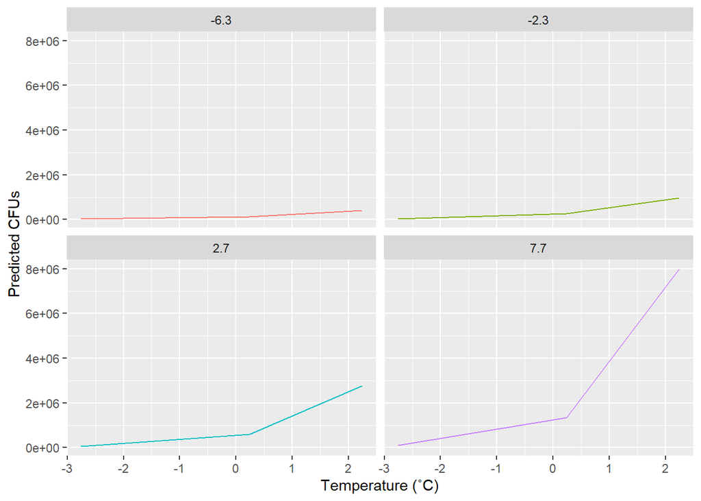

```r
marginalmeanspreds <- ggpredict(z3, terms = c("Temperature","Age"))

ggplot(marginalmeanspreds, aes(x=x,y=predicted,colour=group))+
  geom_line()+
  facet_wrap(~group)+
  labs(x = "Temperature (˚C)", y = "Predicted CFUs")+
  theme(legend.position = "none")
```

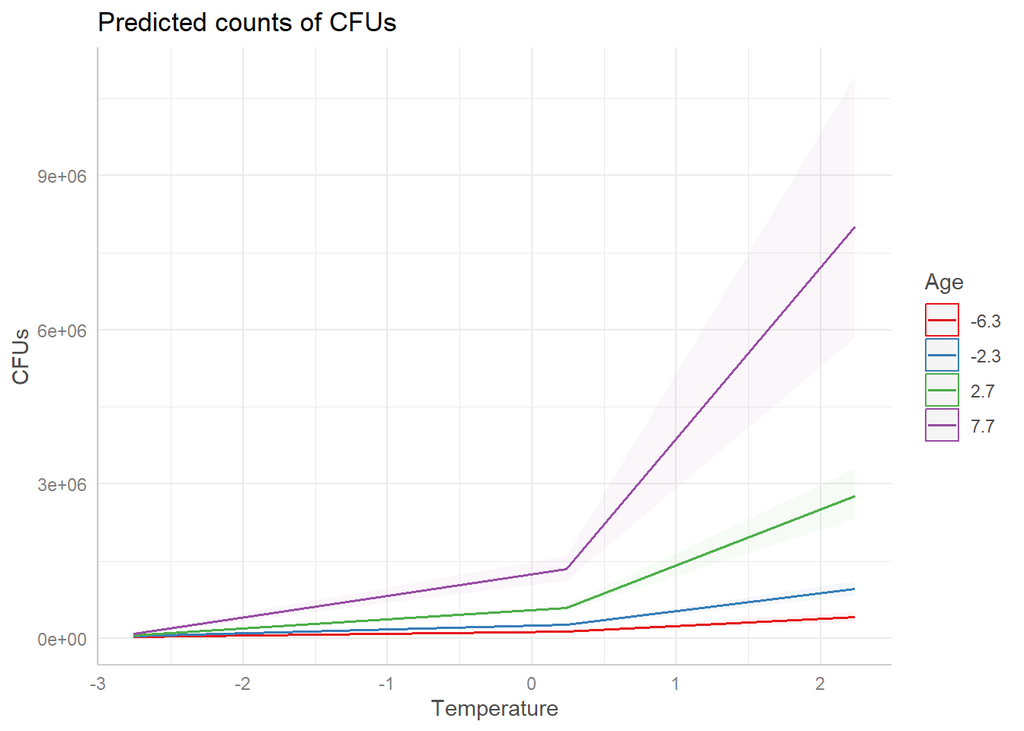

```r
plot(marginalmeanspreds,
     ci=TRUE,
     #add.data=TRUE,
     alpha=0.05)
```

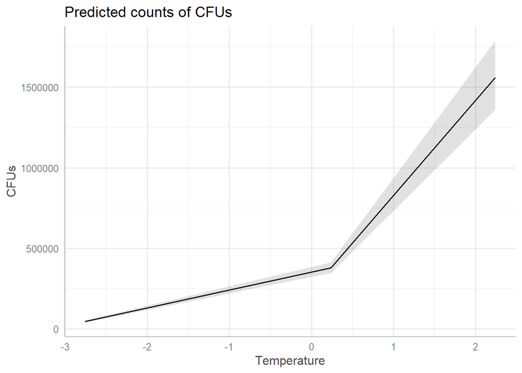

```r
####
library(sjPlot)
library(ggplot2)
theme_set(theme_sjplot())

plot_model(z3, type = "pred", terms = "Temperature")
```

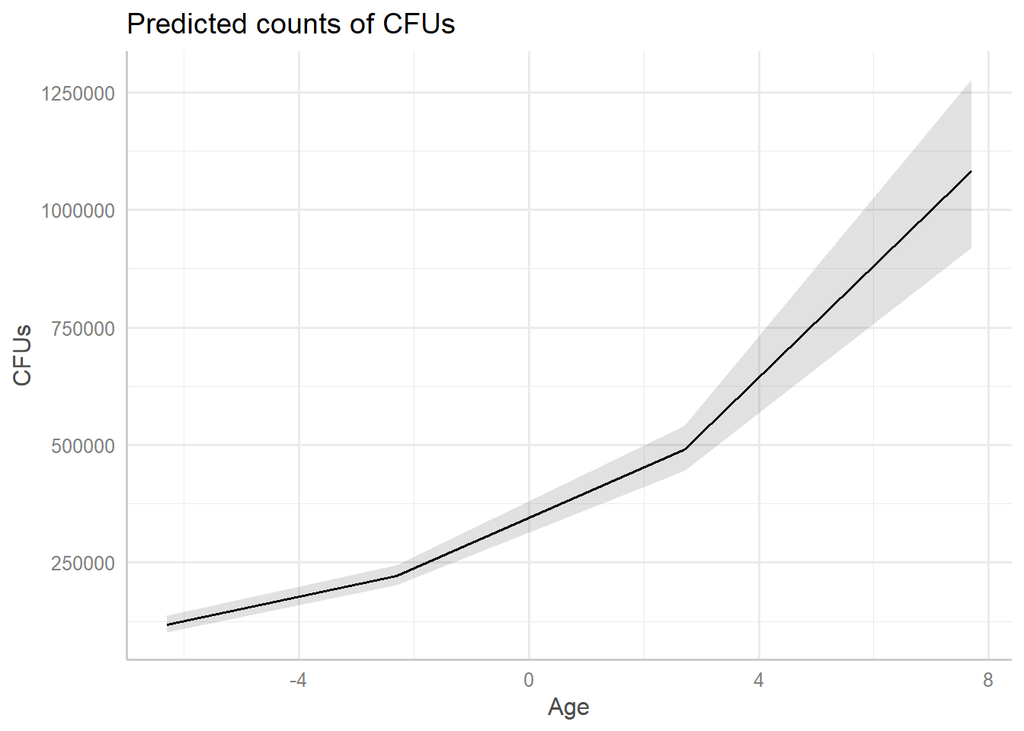

```r
plot_model(z3, type = "pred", terms = "Age")
```

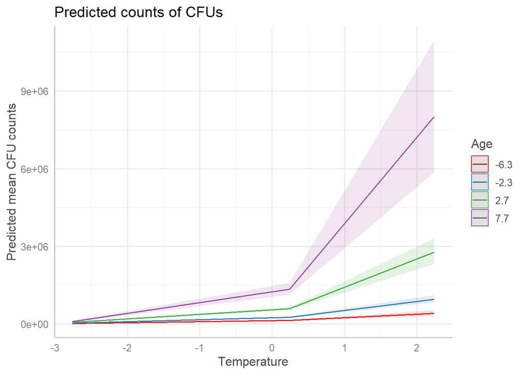

```r
plot_model(z3, type = "pred",
           terms = c("Temperature","Age"),
           axis.title ="Predicted mean CFU counts")
```

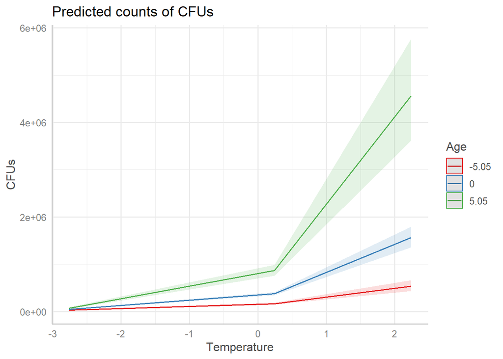

```r
####
plot_model(z3, type = "int", mdrt.values = "meansd")
```

This is another way to determine marginal means:

```r
####
#https://stats.oarc.ucla.edu/r/seminars/interactions-r/#s3
#continuous ~ continuous variable interactions
#data is continuous but can pick examples to plot
library(emmeans)
#mylist <- list(Temperature=27,Age=10)
mylist <- list(Temperature=-2.76,Age=2.7)
emmeans(z3, ~ Temperature*Age, at=mylist)
```

```
##  Temperature Age emmean   SE  df asymp.LCL asymp.UCL
##        -2.76 2.7  56011 5178 Inf     45862     66160
##
## Confidence level used: 0.95
```

```r
#by temperature:
templow <- -2.76 #27
tempmid <- 0.24 #30
temphigh <-2.24 #32

mylist <- list(Temperature = c(templow,tempmid,temphigh))
emtrends(z3, ~Temperature, var="Age",at=mylist)
```

```
##  Temperature Age.trend    SE  df asymp.LCL asymp.UCL
##        -2.76      4028   799 Inf      2462      5594
##         0.24     60216  4493 Inf     51410     69022
##         2.24    321390 36964 Inf    248942    393838
##
## Confidence level used: 0.95
```

```r
#simple slopes for age at low med and high values of temperature
#increasing temperature --> relationship of age on CFUs increases

#range of lower and upper CIs do not include zero - all three are significant

#now plot the cont~cont interaction:
#mylist <- list(Age=seq(0,15,by=1),Temperature=c(templow,tempmid,temphigh))
mylist <- list(Age=seq(-6.30,7.70,by=0.5),Temperature=c(templow,tempmid,temphigh))

mylist
```

```
## $Age
##  [1] -6.3 -5.8 -5.3 -4.8 -4.3 -3.8 -3.3 -2.8 -2.3 -1.8 -1.3 -0.8 -0.3  0.2  0.7
## [16]  1.2  1.7  2.2  2.7  3.2  3.7  4.2  4.7  5.2  5.7  6.2  6.7  7.2  7.7
##
## $Temperature
## [1] -2.76  0.24  2.24
```

```r
emmeansbytemp <- emmip(z3,Temperature~Age,at=mylist, CIs=TRUE,plotit = FALSE)

#now by age:
ageyoung<- -6.30 #1
agelowmid <- -2.30 #5
agehighmid <- 2.70 #10
ageold <- 7.70 #15

mylist <- list(Age = c(ageyoung,agelowmid,agehighmid,ageold))
emtrends(z3, ~Age, var="Temperature",at=mylist)
```

```
##   Age Temperature.trend     SE  df asymp.LCL asymp.UCL
##  -6.3             63686   7043 Inf     49882     77490
##  -2.3            140793   9030 Inf    123095    158492
##   2.7            368308  24873 Inf    319559    417057
##   7.7            940270 106592 Inf    731353   1149188
##
## Confidence level used: 0.95
```

```r
#simple slopes for Temp at young, low mid, high mid, and old values of age
#increasing age --> relationship of Temp on CFUs increases
#range of lower and upper CIs do not include zero - all three are significant

#now plot the cont~cont interaction:
#mylist <- list(Temperature=seq(27,32,by=1),Age = c(ageyoung,agelowmid,agehighmid,ageold))
mylist <- list(Temperature=seq(-2.76,2.24,by=0.5),Age = c(ageyoung,agelowmid,agehighmid,ageold))
mylist
```

```
## $Temperature
##  [1] -2.76 -2.26 -1.76 -1.26 -0.76 -0.26  0.24  0.74  1.24  1.74  2.24
##
## $Age
## [1] -6.3 -2.3  2.7  7.7
```

```r
emmeansbyage <- emmip(z3,Age~Temperature,at=mylist, CIs=TRUE,plotit = FALSE)
      #xlab="Temperature",ylab="Estimated marginal means of CFUs",tlab="Interaction of ",
      #facetlab="label_both")
```

```r
emmeansbytemp$Temperature <- factor(emmeansbytemp$Temperature)
levels(emmeansbytemp$Temperature)
```

```
## [1] "-2.76" "0.24"  "2.24"
```

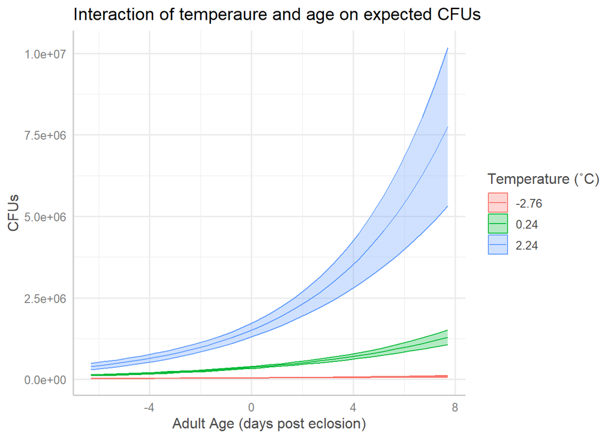

```r
ggplot(data=emmeansbytemp,
       aes(x=Age,y=yvar, color=Temperature)) +
  geom_line()+
  geom_ribbon(aes(ymax=UCL, ymin=LCL, fill=Temperature), alpha=0.3)+
  labs(x="Adult Age (days post eclosion)", y="CFUs", color="Temperature (˚C)",
       fill="Temperature (˚C)",
       title="Interaction of temperaure and age on expected CFUs")
```

```r
##
emmeansbyage$Age <- factor(emmeansbyage$Age)
levels(emmeansbyage$Age)
```

```
## [1] "-6.3" "-2.3" "2.7"  "7.7"
```

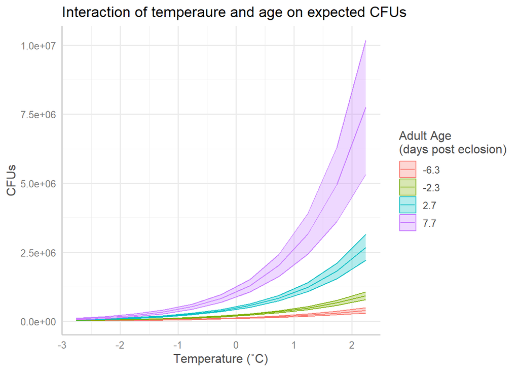

```r
ggplot(data=emmeansbyage,
       aes(x=Temperature,y=yvar, color=Age)) +
  geom_line()+
  geom_ribbon(aes(ymax=UCL, ymin=LCL, fill=Age), alpha=0.3)+
  labs(x="Temperature (˚C)", y="CFUs", color="Adult Age \n(days post eclosion)",
       fill="Adult Age \n(days post eclosion)",
       title="Interaction of temperaure and age on expected CFUs")
```

## Main messages:

1. Temperature, Age, and their interaction significantly impact the infection intensity (expected log CFUs), with warmer temperatures and older ages interacting to increase the infection intensity. At warmer temperatures, older ages increase infection intensity more than at cooler temperatures, and vice versa.
2. Because of the significant interaction, the marginal means are a better way to understand how temperature, age, and their interaction alter infection intensity.
3. The count data were over-dispersed and zero-inflated, best modeled by a zero-inflated negative binomial distribution.